# Genomics Ranges

VOISIN Greg  
May, 19 , 2015

### Specific data structures in R/BioConductor

Some specific data structures are been developped by Bioconductor team:

ExpressionSet/methylSet: Matrix-like dataset plus experiment/sample/feature metadata.. SummarizedExperiment: Analogous to ExpressionSet, but features defined in genomic coordinates. GRanges :Genomic coordinates and associated qualitative and quantitative information, e. g., gene symbol, coverage, p-value.

S3 and S4 structures: particular structures in R to manage a complex data structure.

### R package

Lawrence M, Huber W, PagEs H, Aboyoun P, Carlson M, Gentleman R, Morgan M and Carey V (2013).  
“Software for Computing and Annotating Genomic Ranges.”  
PLoS Computational Biology, 9.

[Available here](http://www.ncbi.nlm.nih.gov/pmc/articles/PMC3738458/pdf/pcbi.1003118.pdf)

### Goal

- manipulate efficently genomic annotations and alignments in high-throughput data
- store informations such as genomic intervals, score …

### Three Data structures

- Iranges, describes one interval
- Granges, describes one transcript (for exemple)
- GrangesList, describes all transcripts of a given gene (for exemple)

### Basic information (not optional) of Granges object

**seqnames**: define the chromosome  
**ranges**: define the boundaries of the element ( gene, exons, TFBS…). start/end  
**strand** : +/-/*

Note1: the start is always the left position and the end the right, even when the range is on the minus strand.  
Note2: seqnames/interval/strand are used for Granges objects comparison.

### metadata informations included in Granges object

Extra column of informations. accessor mcols()

### Basic operations on Granges object

GRanges objects are considered vector-like objects

- length()
- names()
- subsetting
- c()
- comparison : ==, !=, match(), %in%, duplicated(), unique() …

### Complex Operations on Granges object

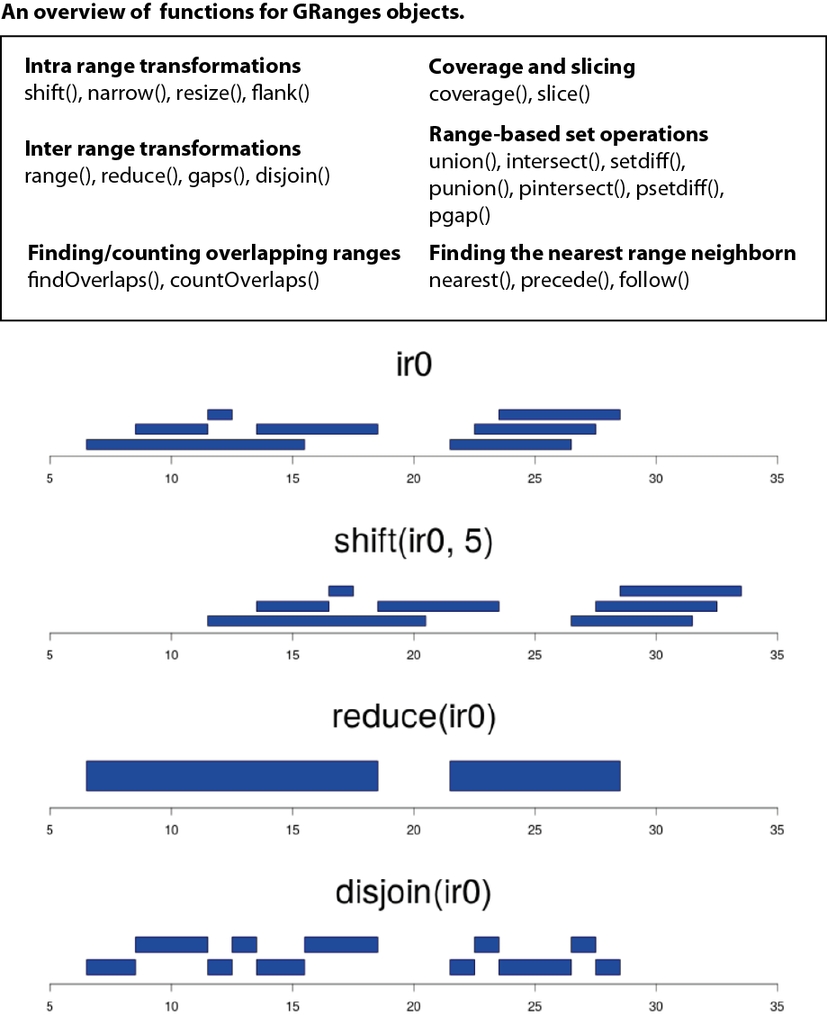

### GRangeList

storing a list of compatible GRanges objects.

Compatible : relative to the same genome same metadata columns

GRanges objects are considered list-like objects

Some functions work very well with this kind of list: elementLengths(GRangeList obj) shift() reduce() …

### Bioconductor tutorial

[here](http://www.bioconductor.org/help/course-materials/2015/SeattleApr2015/B_GenomicRanges.html)